# Biomass analysis (PatchSizePilot)

Emanuele Giacomuzzo

2022-07-07

## Biomass

### Aim

Here I study how **biomass density** changes across treatments in the PatchSizePilot. In particular, I’m studying how biomass density changes across:

- ecosystems of different size (this is the case in nature, but we need to make sure that it’s the case also in our experiment)
- ecosystems that are connected (through the flow of nutrients) to an ecosystem of the same size or to an ecosystem that is larger
- meta-ecosystems in which patch size is the same or in which one patch has most of the area (we keep the total area of the meta-ecosystem constant)

### Data manipulation

#### Import

```r
culture_info = read.csv(here("data", "PatchSizePilot_culture_info.csv"), header = TRUE)
load(here("data", "population", "t0.RData")); t0 = pop_output
load(here("data", "population", "t1.RData")); t1 = pop_output
load(here("data", "population", "t2.RData")); t2 = pop_output
load(here("data", "population", "t3.RData")); t3 = pop_output
load(here("data", "population", "t4.RData")); t4 = pop_output
load(here("data", "population", "t5.RData")); t5 = pop_output
load(here("data", "population", "t6.RData")); t6 = pop_output
load(here("data", "population", "t7.RData")); t7 = pop_output
rm(pop_output)
```

#### Tidy

```r
t0$time = NA
t1$time = NA

t0$replicate_video = 1:12 #In t1 I took 12 videos of a single
t1$replicate_video = 1 #In t1 I took only 1 video/culture
t2$replicate_video = 1 #In t2 I took only 1 video/culture
t3$replicate_video = 1 #In t3 I took only 1 video/culture
t4$replicate_video = 1 #In t4 I took only 1 video/culture
t5$replicate_video = 1 #In t5 I took only 1 video/culture

t6 = t6 %>%
  rename(replicate_video = replicate)
t7 = t7 %>%
  rename(replicate_video = replicate)

#Create an elongated version of t0 so that each of the 110 cultures can have 12 video replicates at t0.
elongating_t0 = NULL
for (video in 1:nrow(t0)){
  for (ID in 1:nrow(culture_info)) {
    elongating_t0 = rbind(elongating_t0, t0[video,])
  }
}

ID_vector = rep(1:nrow(culture_info),
                times = nrow(t0))

elongating_t0$culture_ID = ID_vector

t0 = merge(culture_info,elongating_t0, by="culture_ID")
t1 = merge(culture_info,t1, by = "culture_ID")
t2 = merge(culture_info,t2, by = "culture_ID")
t3 = merge(culture_info,t3, by = "culture_ID")
t4 = merge(culture_info,t4, by = "culture_ID")
t5 = merge(culture_info,t5, by = "culture_ID")
t6 = merge(culture_info,t6, by = "culture_ID")
t7 = merge(culture_info,t7, by = "culture_ID")
ds = rbind(t0, t1, t2, t3, t4, t5, t6, t7)
rm(elongating_t0, t0, t1, t2, t3, t4, t5, t6, t7)

ds$time_point[ds$time_point=="t0"] = 0
ds$time_point[ds$time_point=="t1"] = 1
ds$time_point[ds$time_point=="t2"] = 2
ds$time_point[ds$time_point=="t3"] = 3
ds$time_point[ds$time_point=="t4"] = 4
ds$time_point[ds$time_point=="t5"] = 5
ds$time_point[ds$time_point=="t6"] = 6
ds$time_point[ds$time_point=="t7"] = 7
ds$time_point = as.character(ds$time_point)

ds$day = NA
ds$day[ds$time_point== 0] = 0
ds$day[ds$time_point== 1] = 4
ds$day[ds$time_point== 2] = 8
ds$day[ds$time_point== 3] = 12
ds$day[ds$time_point== 4] = 16
ds$day[ds$time_point== 5] = 20
ds$day[ds$time_point== 6] = 24
ds$day[ds$time_point== 7] = 28

ds = ds %>%
  select(culture_ID,
         patch_size,
         disturbance,
         metaecosystem_type,
         bioarea_per_volume,
         replicate_video,
         time_point,
         day,
         metaecosystem,
         system_nr,
         eco_metaeco_type)

ds = ds[, c("culture_ID",
            "system_nr",
            "disturbance",
            "time_point",
            "day",
            "patch_size",
            "metaecosystem",
            "metaecosystem_type",
            "eco_metaeco_type",
            "replicate_video",
            "bioarea_per_volume")]

ds$eco_metaeco_type = factor(ds$eco_metaeco_type,
                             levels = c('S',
                                        'S (S_S)',
                                        'S (S_L)',
                                        'M',
                                        'M (M_M)',
                                        'L',
                                        'L (L_L)',
                                        'L (S_L)'))

#ds$patch_size = factor(ds$patch_size,
#                        levels = c ('S', 'M', 'L'))

#ds$metaecosystem_type = factor(ds$metaecosystem_type,
#levels = c ('S_S', 'M_M', 'L_L', 'S_L'))

ecosystems_to_take_off = 60 #Culture number 60 because it was spilled
ds = ds %>%
  filter(! culture_ID %in% ecosystems_to_take_off)
```

#### Create regional data set

```r
ds_regional = ds %>%
  filter(metaecosystem == "yes") %>%
  group_by(culture_ID,
           system_nr,
           disturbance,
           day,
           time_point,
           patch_size,
           metaecosystem_type) %>%
  summarise(patch_mean_bioarea_across_videos = mean(bioarea_per_volume)) %>%
  group_by(system_nr, disturbance, day, time_point, metaecosystem_type) %>%
  summarise(regional_mean_bioarea = mean(patch_mean_bioarea_across_videos))

metaecosystems_to_take_off = 40 #System 40 was the system of culture 60 that I spilled
ds_regional = ds_regional %>%
  filter(! system_nr %in% metaecosystems_to_take_off)
```

### Regional biomass

#### Medium-medium vs Small-large

We want to understand if the regional biomass produced by an ecosystem with a small and a large patch (metaecosystem_type = S_L) is lower than the regional biomass produced by an ecosystem with two medium patches (metaecosystem_type = M_M).

##### Plot

Let’s start by plotting the single ecosystems to see that everything is fine. To make the patterns clear let’s plot the low disturbance and high disturbance in two different figures.

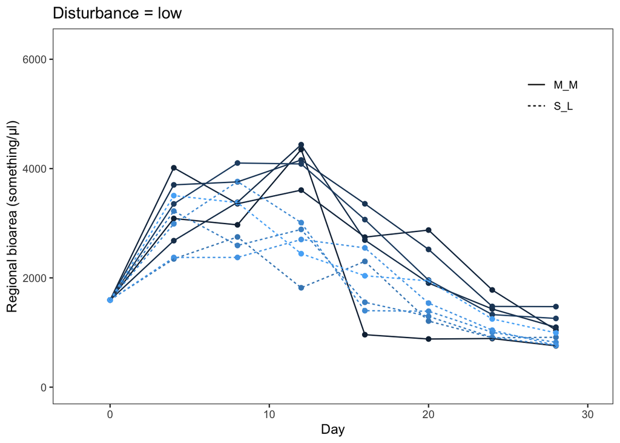

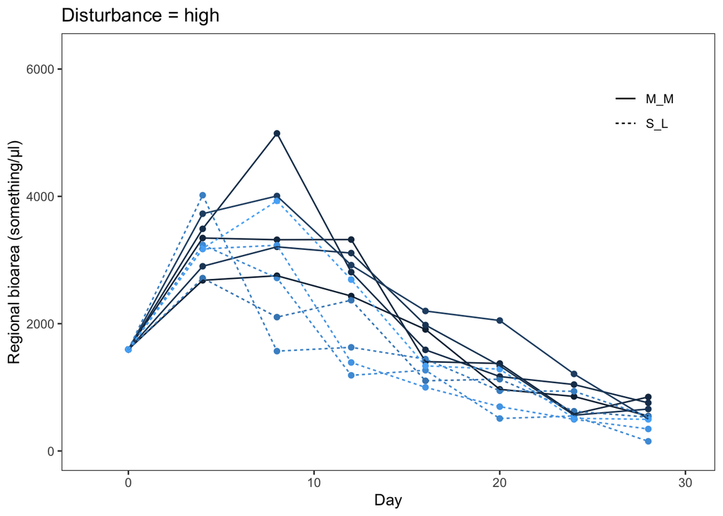

Let’s then show these data as boxplots.

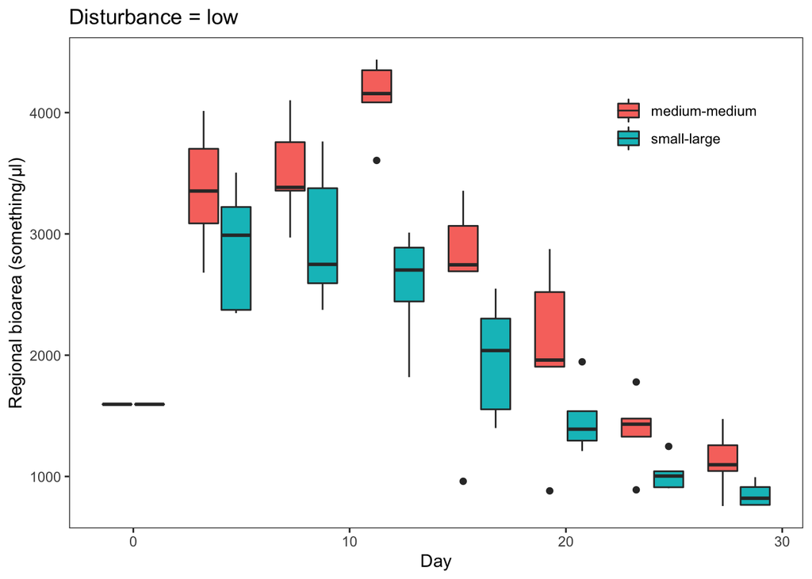

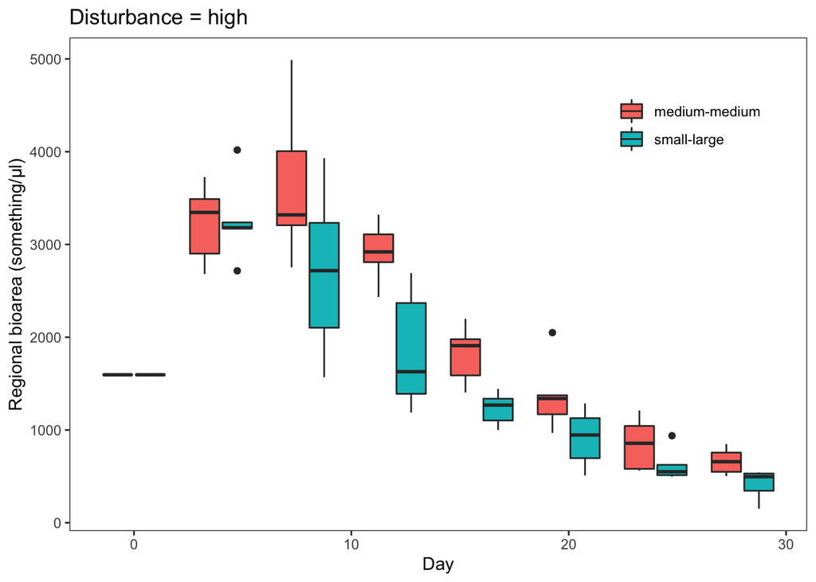

We can see that the regional biomass was higher for meta-ecosystems with the same size, regardless of disturbance. As both disturbance levels showed the same pattern, I would just keep the one with low disturbance in the publication, as it shows a stronger pattern.

##### Tidy

First of all, let’s modify the data set including the regional biomass of our meta-ecosystems. In this data set, we want to have the regional biomass of the meta-ecosystems (averaged first across videos and then across patches) in which we:

- Include only the meta-ecosystems in which patches had both medium size (metaecosystem_type = M_M) and meta-ecosystems in which patches had one a small size and the other large size (metaecosystem_type = S_L).
- Take off the first two point (day 0 and day = 4). This is because the first perturbation happened only at day 5.

```r
ds_regional_MM_SL_t2t7 = ds_regional %>%
    filter (metaecosystem_type == "M_M" | metaecosystem_type == "S_L",
            time_point >= 2)
```

##### Model selection

Let’s start from the largest mixed effect model makes sense to construct. This will include:

- As fixed effect: metaecosystem type (M), disturbance (D), and their interaction (M * D)
- As random effect (random intercept and slope): day and the number of the metaecosystem (system_nr).

We are actually going to construct two full models. One with the correlated and one with the uncorrelated random slopes and intercept, the other without

*(1) Should we keep the correlation between intercept and slopes (|)?*

```r
full_model_correlated = lmer(regional_mean_bioarea ~
                             metaecosystem_type  +
                             disturbance +
                             metaecosystem_type * disturbance +
                             (metaecosystem_type | day) +
                             (disturbance | day) +
                             (metaecosystem_type*disturbance  | day) +
                             (1 | system_nr) ,
                             data = ds_regional_MM_SL_t2t7,
                             REML = FALSE)

full_model_uncorrelated = lmer(regional_mean_bioarea ~
                    metaecosystem_type  +
                    disturbance +
                    metaecosystem_type * disturbance +
                    (metaecosystem_type || day) +
                    (disturbance || day) +
                    (metaecosystem_type*disturbance  || day) +
                    (1 | system_nr) ,
                  data = ds_regional_MM_SL_t2t7,
                  REML = FALSE)

anova(full_model_uncorrelated, full_model_correlated)
```

```
## Data: ds_regional_MM_SL_t2t7
## Models:
## full_model_correlated: regional_mean_bioarea ~ metaecosystem_type + disturbance + metaecosystem_type * disturbance + (metaecosystem_type | day) + (disturbance | day) + (metaecosystem_type * disturbance | day) + (1 | system_nr)
## full_model_uncorrelated: regional_mean_bioarea ~ metaecosystem_type + disturbance + metaecosystem_type * disturbance + ((1 | day) + (0 + metaecosystem_type | day)) + ((1 | day) + (0 + disturbance | day)) + ((1 | day) + (0 + metaecosystem_type | day) + (0 + disturbance | day) + (0 + metaecosystem_…
##                         npar    AIC    BIC  logLik deviance Chisq Df Pr(>Chisq)
## full_model_correlated     22 1881.2 1942.5 -918.58   1837.2
## full_model_uncorrelated   31 1899.3 1985.7 -918.63   1837.3     0  9          1
```

Yes (according to BIC and AIC). Interestingly enough, the p-value is 1 (how should I interpret this?).

*(2) Should we keep M ** D ?

```r
no_interaction_model = lmer(regional_mean_bioarea ~
                              metaecosystem_type +
                              disturbance  +
                              (metaecosystem_type | day) +
                              (disturbance | day) +
                              (1 | system_nr),
                            data = ds_regional_MM_SL_t2t7,
                            REML = FALSE)

anova(full_model_correlated, no_interaction_model)
```

```
## Data: ds_regional_MM_SL_t2t7
## Models:
## no_interaction_model: regional_mean_bioarea ~ metaecosystem_type + disturbance + (metaecosystem_type | day) + (disturbance | day) + (1 | system_nr)
## full_model_correlated: regional_mean_bioarea ~ metaecosystem_type + disturbance + metaecosystem_type * disturbance + (metaecosystem_type | day) + (disturbance | day) + (metaecosystem_type * disturbance | day) + (1 | system_nr)
##                       npar    AIC    BIC  logLik deviance  Chisq Df Pr(>Chisq)
## no_interaction_model    11 1861.7 1892.4 -919.86   1839.7
## full_model_correlated   22 1881.2 1942.5 -918.58   1837.2 2.5592 11     0.9954
```

No (according to AIC and BIC). The p-value is also here almost 1 (how should I interpret this?).

*(3) Should we keep (M | day)?*

```r
no_metaeco_slopes_model = lmer(regional_mean_bioarea ~
                                 metaecosystem_type +
                                 disturbance  +
                                 (disturbance | day) +
                                 (1 | system_nr),
                               data = ds_regional_MM_SL_t2t7,
                               REML = FALSE)

anova(no_interaction_model, no_metaeco_slopes_model)
```

```
## Data: ds_regional_MM_SL_t2t7
## Models:
## no_metaeco_slopes_model: regional_mean_bioarea ~ metaecosystem_type + disturbance + (disturbance | day) + (1 | system_nr)
## no_interaction_model: regional_mean_bioarea ~ metaecosystem_type + disturbance + (metaecosystem_type | day) + (disturbance | day) + (1 | system_nr)
##                         npar    AIC    BIC  logLik deviance  Chisq Df
## no_metaeco_slopes_model    8 1871.0 1893.2 -927.48   1855.0
## no_interaction_model      11 1861.7 1892.4 -919.86   1839.7 15.239  3
##                         Pr(>Chisq)
## no_metaeco_slopes_model
## no_interaction_model      0.001623 **
## ---
## Signif. codes:  0 '***' 0.001 '**' 0.01 '*' 0.05 '.' 0.1 ' ' 1
```

Yes (according to AIC and BIC - however, BIC is only slightly lower). The p-value is really low (0.002).

*(4) Should we keep (D | day)?*

```r
no_disturbance_slopes_model = lmer(regional_mean_bioarea ~
                                     metaecosystem_type +
                                     disturbance  +
                                     (metaecosystem_type | day) +
                                     (1 | system_nr),
                                   data = ds_regional_MM_SL_t2t7,
                                   REML = FALSE)

anova(no_interaction_model, no_disturbance_slopes_model)
```

```
## Data: ds_regional_MM_SL_t2t7
## Models:
## no_disturbance_slopes_model: regional_mean_bioarea ~ metaecosystem_type + disturbance + (metaecosystem_type | day) + (1 | system_nr)
## no_interaction_model: regional_mean_bioarea ~ metaecosystem_type + disturbance + (metaecosystem_type | day) + (disturbance | day) + (1 | system_nr)
##                             npar    AIC    BIC  logLik deviance  Chisq Df
## no_disturbance_slopes_model    8 1860.6 1882.9 -922.31   1844.6
## no_interaction_model          11 1861.7 1892.4 -919.86   1839.7 4.9107  3
##                             Pr(>Chisq)
## no_disturbance_slopes_model
## no_interaction_model            0.1785
```

*(5) Should we keep (1 | system_nr)?*

```r
no_system_nr = lmer(regional_mean_bioarea ~
                      metaecosystem_type +
                      disturbance  +
                      (metaecosystem_type | day),
                    data = ds_regional_MM_SL_t2t7,
                    REML = FALSE)

anova(no_disturbance_slopes_model, no_system_nr)
```

```
## Data: ds_regional_MM_SL_t2t7
## Models:
## no_system_nr: regional_mean_bioarea ~ metaecosystem_type + disturbance + (metaecosystem_type | day)
## no_disturbance_slopes_model: regional_mean_bioarea ~ metaecosystem_type + disturbance + (metaecosystem_type | day) + (1 | system_nr)
##                             npar    AIC    BIC  logLik deviance Chisq Df
## no_system_nr                   7 1861.5 1881.0 -923.75   1847.5
## no_disturbance_slopes_model    8 1860.6 1882.9 -922.31   1844.6 2.881  1
##                             Pr(>Chisq)
## no_system_nr
## no_disturbance_slopes_model    0.08963 .
## ---
## Signif. codes:  0 '***' 0.001 '**' 0.01 '*' 0.05 '.' 0.1 ' ' 1
```

Yes according to AIC (but no according to BIC). The p-value is low (0.09).

*Should we keep these parameters?*

| Parameter | AIC | BIC |
| --- | --- | --- |
| \| (correlation) | Yes | Yes |
| M * D | No | No |
| (M \| t) | Yes | Yes (but slightly lower) |
| *(D \| t)* | No (but slightly lower) | No |
| *(1 \| ID)* | Yes | No |

To make sure everything is okay, let’s take a look at all our models.

```r
anova(full_model_correlated, full_model_uncorrelated, no_interaction_model, no_metaeco_slopes_model, no_disturbance_slopes_model, no_system_nr)
```

```
## Data: ds_regional_MM_SL_t2t7
## Models:
## no_system_nr: regional_mean_bioarea ~ metaecosystem_type + disturbance + (metaecosystem_type | day)
## no_metaeco_slopes_model: regional_mean_bioarea ~ metaecosystem_type + disturbance + (disturbance | day) + (1 | system_nr)
## no_disturbance_slopes_model: regional_mean_bioarea ~ metaecosystem_type + disturbance + (metaecosystem_type | day) + (1 | system_nr)
## no_interaction_model: regional_mean_bioarea ~ metaecosystem_type + disturbance + (metaecosystem_type | day) + (disturbance | day) + (1 | system_nr)
## full_model_correlated: regional_mean_bioarea ~ metaecosystem_type + disturbance + metaecosystem_type * disturbance + (metaecosystem_type | day) + (disturbance | day) + (metaecosystem_type * disturbance | day) + (1 | system_nr)
## full_model_uncorrelated: regional_mean_bioarea ~ metaecosystem_type + disturbance + metaecosystem_type * disturbance + ((1 | day) + (0 + metaecosystem_type | day)) + ((1 | day) + (0 + disturbance | day)) + ((1 | day) + (0 + metaecosystem_type | day) + (0 + disturbance | day) + (0 + metaecosystem_…
##                             npar    AIC    BIC  logLik deviance   Chisq Df
## no_system_nr                   7 1861.5 1881.0 -923.75   1847.5
## no_metaeco_slopes_model        8 1871.0 1893.2 -927.48   1855.0  0.0000  1
## no_disturbance_slopes_model    8 1860.6 1882.9 -922.31   1844.6 10.3288  0
## no_interaction_model          11 1861.7 1892.4 -919.86   1839.7  4.9107  3
## full_model_correlated         22 1881.2 1942.5 -918.58   1837.2  2.5592 11
## full_model_uncorrelated       31 1899.3 1985.7 -918.63   1837.3  0.0000  9
##                             Pr(>Chisq)
## no_system_nr
## no_metaeco_slopes_model         1.0000
## no_disturbance_slopes_model
## no_interaction_model            0.1785
## full_model_correlated           0.9954
## full_model_uncorrelated         1.0000
```

Odd, in some of the models chi squared is zero and in some the degrees of freedom are zero.

The best model according to AIC should be M + D + (M | day) + (1 | system number) (`no_disturbance_slopes_model`). However, it has zero degrees of freedom.

So, the models I’m going to consider as possible models are the following ones:

- M + D + (M | t) + (1 | ID) [Best model according to AIC]
- M + D + (M | t) + (D | t) + (1 | ID) [Best model according to AIC with (D | t), which had a slightly higher AIC]
- M + D + (M | t) [Best model according to BIC]
- M + D [Best model according to BIC without (M | t), which had only a slightly higher BIC]

##### Time fitting

Here we want to fit how biomass changes across time to a function. The biomass of our meta-ecosystems looks like this.

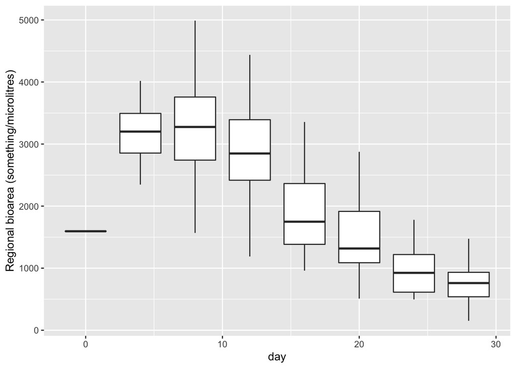

To fit these data, we need to produce (and parameterise) a function that resemble how the biomass first increases and then decreases.

Hank produced the following function:

$$biomass = a_4 * (day - a_5) * e^{a_1(day
- a_5)}$$

If we parameterise the function and then plot, it looks as follows.

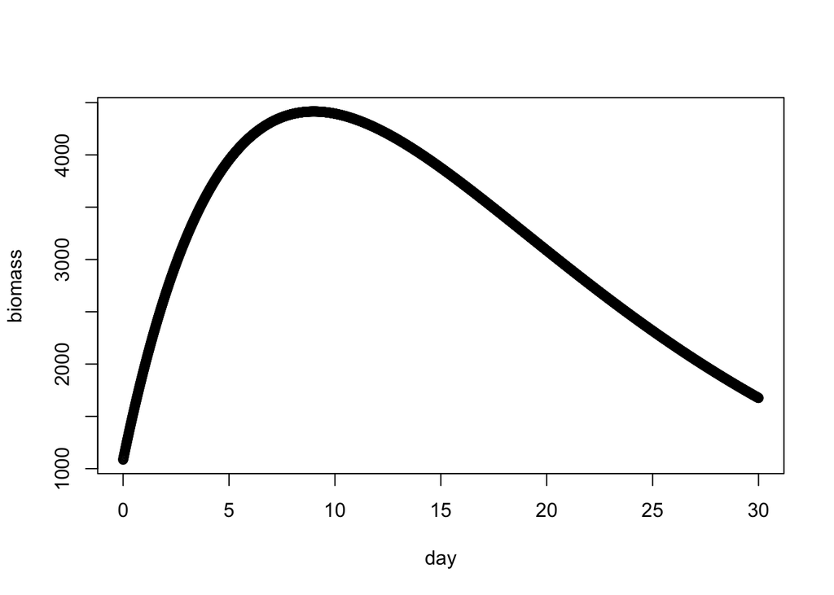

```r
a1 = -0.1
a4 = 1200
a5 = -1

day = seq(0, 30, 0.01)
biomass = a4*(day-a5) * exp(a1*(day-a5))
plot(biomass ~ day)
```

Now, let’s find the best parameters (a1, a4, a5) that fit our data.

```r
model$m$getPars()
```

```
##           a1           a4           a5
##   -0.1336182 1216.4268967   -1.6147345
```

And now let’s plot the function to see how it fits our data.

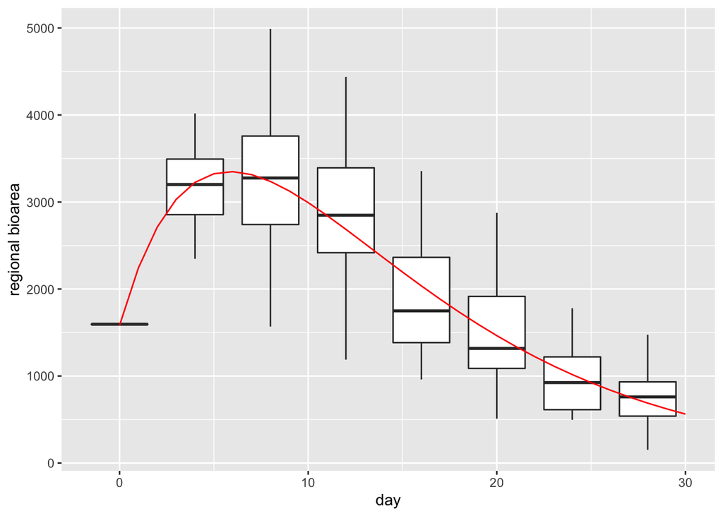

Let’s then include our predictions into the data set.

```r
ds_regional_predicted_shrunk_type = ds_regional %>%
  mutate(predicted_from_time = a4*(day-a5)*exp(a1*(day-a5))) %>%
  filter(metaecosystem_type == "S_L" | metaecosystem_type == "M_M")
```

##### Time as fixed effect

Let’s now work using the fitted data that we found in the previous section.

##### Tidy

```r
ds_regional_predicted_shrunk_type_n_day = ds_regional_predicted_shrunk_type %>%
  filter(time_point >= 2)
```

##### Model selection

Let’s start from the full model.

```r
model_slopes_correlated = lmer(regional_mean_bioarea ~
                            predicted_from_time +
                            metaecosystem_type  +
                            disturbance +
                            predicted_from_time * metaecosystem_type +
                            predicted_from_time * disturbance +
                            metaecosystem_type * disturbance +
                            predicted_from_time * metaecosystem_type * disturbance +
                            (predicted_from_time | system_nr),
                        data = ds_regional_predicted_shrunk_type_n_day,
                        REML = FALSE)
```

*(1) Should we keep the correlation in (T | ID)?*

```r
model_slopes_uncorrelated = lmer(regional_mean_bioarea ~
                            predicted_from_time +
                            metaecosystem_type  +
                            disturbance +
                            predicted_from_time * metaecosystem_type +
                            predicted_from_time * disturbance +
                            metaecosystem_type * disturbance +
                            predicted_from_time * metaecosystem_type * disturbance +
                            (predicted_from_time || system_nr),
                        data = ds_regional_predicted_shrunk_type_n_day,
                        REML = FALSE,
                        control = lmerControl(optimizer = "Nelder_Mead"))
anova(model_slopes_uncorrelated, model_slopes_correlated)
```

```
## Data: ds_regional_predicted_shrunk_type_n_day
## Models:
## model_slopes_uncorrelated: regional_mean_bioarea ~ predicted_from_time + metaecosystem_type + disturbance + predicted_from_time * metaecosystem_type + predicted_from_time * disturbance + metaecosystem_type * disturbance + predicted_from_time * metaecosystem_type * disturbance + ((1 | system_nr) +…
## model_slopes_correlated: regional_mean_bioarea ~ predicted_from_time + metaecosystem_type + disturbance + predicted_from_time * metaecosystem_type + predicted_from_time * disturbance + metaecosystem_type * disturbance + predicted_from_time * metaecosystem_type * disturbance + (predicted_from_time…
##                           npar    AIC    BIC  logLik deviance  Chisq Df
## model_slopes_uncorrelated   11 1841.8 1872.5 -909.90   1819.8
## model_slopes_correlated     12 1842.7 1876.2 -909.35   1818.7 1.1016  1
##                           Pr(>Chisq)
## model_slopes_uncorrelated
## model_slopes_correlated       0.2939
```

No (according to AIC and BIC - however, AIC is only slightly lower).

*(2) Should we keep T ** M?

```r
model_no_TM = lmer(regional_mean_bioarea ~
                            predicted_from_time +
                            metaecosystem_type  +
                            disturbance +
                            predicted_from_time * disturbance +
                            metaecosystem_type * disturbance +
                            predicted_from_time * metaecosystem_type * disturbance +
                            (predicted_from_time || system_nr),
               data = ds_regional_predicted_shrunk_type_n_day,
               REML = FALSE,
               control = lmerControl (optimizer = "Nelder_Mead")
               )
anova(model_slopes_uncorrelated, model_no_TM)
```

```
## Data: ds_regional_predicted_shrunk_type_n_day
## Models:
## model_slopes_uncorrelated: regional_mean_bioarea ~ predicted_from_time + metaecosystem_type + disturbance + predicted_from_time * metaecosystem_type + predicted_from_time * disturbance + metaecosystem_type * disturbance + predicted_from_time * metaecosystem_type * disturbance + ((1 | system_nr) +…
## model_no_TM: regional_mean_bioarea ~ predicted_from_time + metaecosystem_type + disturbance + predicted_from_time * disturbance + metaecosystem_type * disturbance + predicted_from_time * metaecosystem_type * disturbance + ((1 | system_nr) + (0 + predicted_from_time | system_nr))
##                           npar    AIC    BIC logLik deviance Chisq Df
## model_slopes_uncorrelated   11 1841.8 1872.5 -909.9   1819.8
## model_no_TM                 11 1841.8 1872.5 -909.9   1819.8     0  0
##                           Pr(>Chisq)
## model_slopes_uncorrelated
## model_no_TM
```

This is really wired. Df = 0. Let’s then say no then.

*(3) Should we keep T ** D?

```r
model_no_TD = lmer(regional_mean_bioarea ~
                            predicted_from_time +
                            metaecosystem_type  +
                            disturbance +
                            metaecosystem_type * disturbance +
                            predicted_from_time * metaecosystem_type * disturbance +
                            (predicted_from_time || system_nr),
               data = ds_regional_predicted_shrunk_type_n_day,
               REML = FALSE,
               control = lmerControl (optimizer = "Nelder_Mead"))
anova(model_no_TM, model_no_TD)
```

```
## Data: ds_regional_predicted_shrunk_type_n_day
## Models:
## model_no_TM: regional_mean_bioarea ~ predicted_from_time + metaecosystem_type + disturbance + predicted_from_time * disturbance + metaecosystem_type * disturbance + predicted_from_time * metaecosystem_type * disturbance + ((1 | system_nr) + (0 + predicted_from_time | system_nr))
## model_no_TD: regional_mean_bioarea ~ predicted_from_time + metaecosystem_type + disturbance + metaecosystem_type * disturbance + predicted_from_time * metaecosystem_type * disturbance + ((1 | system_nr) + (0 + predicted_from_time | system_nr))
##             npar    AIC    BIC logLik deviance Chisq Df Pr(>Chisq)
## model_no_TM   11 1841.8 1872.5 -909.9   1819.8
## model_no_TD   11 1841.8 1872.5 -909.9   1819.8     0  0
```

This is really wired. Df = 0. Let’s then say no then.

*(4) Should we keep M * D?*

```r
model_no_MD = lmer(regional_mean_bioarea ~
                            predicted_from_time +
                            metaecosystem_type  +
                            disturbance +
                            predicted_from_time * metaecosystem_type * disturbance +
                            (predicted_from_time || system_nr),
               data = ds_regional_predicted_shrunk_type_n_day,
               REML = FALSE,
               control = lmerControl (optimizer = "Nelder_Mead"))
anova(model_no_TD, model_no_MD)
```

```
## Data: ds_regional_predicted_shrunk_type_n_day
## Models:
## model_no_TD: regional_mean_bioarea ~ predicted_from_time + metaecosystem_type + disturbance + metaecosystem_type * disturbance + predicted_from_time * metaecosystem_type * disturbance + ((1 | system_nr) + (0 + predicted_from_time | system_nr))
## model_no_MD: regional_mean_bioarea ~ predicted_from_time + metaecosystem_type + disturbance + predicted_from_time * metaecosystem_type * disturbance + ((1 | system_nr) + (0 + predicted_from_time | system_nr))
##             npar    AIC    BIC logLik deviance Chisq Df Pr(>Chisq)
## model_no_TD   11 1841.8 1872.5 -909.9   1819.8
## model_no_MD   11 1841.8 1872.5 -909.9   1819.8     0  0
```

This is really wired. Df = 0. Let’s then say no then.

*(5) Should we keep T * M * D?*

```r
model_no_TMD = lmer(regional_mean_bioarea ~
                            predicted_from_time +
                            metaecosystem_type  +
                            disturbance +
                            (predicted_from_time || system_nr),
               data = ds_regional_predicted_shrunk_type_n_day,
               REML = FALSE,
               control = lmerControl (optimizer = "Nelder_Mead"))

anova(model_no_MD, model_no_TMD)
```

```
## Data: ds_regional_predicted_shrunk_type_n_day
## Models:
## model_no_TMD: regional_mean_bioarea ~ predicted_from_time + metaecosystem_type + disturbance + ((1 | system_nr) + (0 + predicted_from_time | system_nr))
## model_no_MD: regional_mean_bioarea ~ predicted_from_time + metaecosystem_type + disturbance + predicted_from_time * metaecosystem_type * disturbance + ((1 | system_nr) + (0 + predicted_from_time | system_nr))
##              npar    AIC    BIC  logLik deviance Chisq Df Pr(>Chisq)
## model_no_TMD    7 1844.3 1863.8 -915.15   1830.3
## model_no_MD    11 1841.8 1872.5 -909.90   1819.8 10.49  4    0.03294 *
## ---
## Signif. codes:  0 '***' 0.001 '**' 0.01 '*' 0.05 '.' 0.1 ' ' 1
```

Yes according to AIC (but no according to BIC).

*(6) Should we keep (T || ID)?*

```r
model_no_random_slope = lmer(regional_mean_bioarea ~
                            predicted_from_time +
                            metaecosystem_type  +
                            disturbance +
                            (1 | system_nr),
               data = ds_regional_predicted_shrunk_type_n_day,
               REML = FALSE,
               control = lmerControl (optimizer = "Nelder_Mead"))

anova(model_no_MD, model_no_random_slope)
```

```
## Data: ds_regional_predicted_shrunk_type_n_day
## Models:
## model_no_random_slope: regional_mean_bioarea ~ predicted_from_time + metaecosystem_type + disturbance + (1 | system_nr)
## model_no_MD: regional_mean_bioarea ~ predicted_from_time + metaecosystem_type + disturbance + predicted_from_time * metaecosystem_type * disturbance + ((1 | system_nr) + (0 + predicted_from_time | system_nr))
##                       npar    AIC    BIC  logLik deviance Chisq Df Pr(>Chisq)
## model_no_random_slope    6 1842.3 1859.0 -915.15   1830.3
## model_no_MD             11 1841.8 1872.5 -909.90   1819.8 10.49  5    0.06249 .
## ---
## Signif. codes:  0 '***' 0.001 '**' 0.01 '*' 0.05 '.' 0.1 ' ' 1
```

Yes according to AIC (but no according to BIC).

*(7) Should we introduce the correlation (T | ID) ?*

```r
model_no_MD_correlated = lmer(regional_mean_bioarea ~
                            predicted_from_time +
                            metaecosystem_type  +
                            disturbance +
                            predicted_from_time * metaecosystem_type * disturbance +
                            (predicted_from_time | system_nr),
               data = ds_regional_predicted_shrunk_type_n_day,
               REML = FALSE,
               control = lmerControl (optimizer = "Nelder_Mead"))
anova(model_no_MD, model_no_MD_correlated)
```

```
## Data: ds_regional_predicted_shrunk_type_n_day
## Models:
## model_no_MD: regional_mean_bioarea ~ predicted_from_time + metaecosystem_type + disturbance + predicted_from_time * metaecosystem_type * disturbance + ((1 | system_nr) + (0 + predicted_from_time | system_nr))
## model_no_MD_correlated: regional_mean_bioarea ~ predicted_from_time + metaecosystem_type + disturbance + predicted_from_time * metaecosystem_type * disturbance + (predicted_from_time | system_nr)
##                        npar    AIC    BIC  logLik deviance Chisq Df Pr(>Chisq)
## model_no_MD              11 1841.8 1872.5 -909.90   1819.8
## model_no_MD_correlated   12 1841.5 1875.0 -908.76   1817.5 2.286  1     0.1305
```

Yes according to AIC (but no according to BIC). This is odd as at the beginning the model told us we shouldn’t keep it.

*Should we keep these parameters?*

| Parameter | AIC | BIC |
| --- | --- | --- |
| (T \| ID) (correlation) | No (but only slightly lower) | No |
| T * M | ? | ? |
| T * D | ? | ? |
| M * D | ? | ? |
| T * M * D | Yes | No |
| (T \|\| ID) | Yes | No |

```r
fixed_model = lm(regional_mean_bioarea ~
                            predicted_from_time +
                            metaecosystem_type  +
                            disturbance,
               data = ds_regional_predicted_shrunk_type_n_day)
```

To make sure everything is okay, let’s take a look at all our models.

```r
anova(model_slopes_correlated, model_slopes_uncorrelated, model_no_random_slope, fixed_model) #Only with models df > 0
```

```
## Data: ds_regional_predicted_shrunk_type_n_day
## Models:
## fixed_model: regional_mean_bioarea ~ predicted_from_time + metaecosystem_type + disturbance
## model_no_random_slope: regional_mean_bioarea ~ predicted_from_time + metaecosystem_type + disturbance + (1 | system_nr)
## model_slopes_uncorrelated: regional_mean_bioarea ~ predicted_from_time + metaecosystem_type + disturbance + predicted_from_time * metaecosystem_type + predicted_from_time * disturbance + metaecosystem_type * disturbance + predicted_from_time * metaecosystem_type * disturbance + ((1 | system_nr) +…
## model_slopes_correlated: regional_mean_bioarea ~ predicted_from_time + metaecosystem_type + disturbance + predicted_from_time * metaecosystem_type + predicted_from_time * disturbance + metaecosystem_type * disturbance + predicted_from_time * metaecosystem_type * disturbance + (predicted_from_time…
##                           npar    AIC    BIC  logLik deviance   Chisq Df
## fixed_model                  5 1841.7 1855.6 -915.84   1831.7
## model_no_random_slope        6 1842.3 1859.0 -915.15   1830.3  1.3783  1
## model_slopes_uncorrelated   11 1841.8 1872.5 -909.90   1819.8 10.4897  5
## model_slopes_correlated     12 1842.7 1876.2 -909.35   1818.7  1.1016  1
##                           Pr(>Chisq)
## fixed_model
## model_no_random_slope        0.24038
## model_slopes_uncorrelated    0.06249 .
## model_slopes_correlated      0.29393
## ---
## Signif. codes:  0 '***' 0.001 '**' 0.01 '*' 0.05 '.' 0.1 ' ' 1
```

```r
#anova(model_slopes_correlated, model_slopes_uncorrelated, model_no_TM, model_no_TD, model_no_MD, model_no_TMD, model_no_random_slope, fixed_model) #With all the models
```

Therefore, the models I will consider are:

*DOESN’t WORK THOUGH (number of observations (=40) <= number of random effects (=40) )

##### Selected models

| model | time_point | AIC | BIC | R2 | R2_fixed | R2_meta_mixed | R2_meta_fixed |
| --- | --- | --- | --- | --- | --- | --- | --- |
| M + D + (M\|t) + (1\|ID) | t2 - t3 | 645.57 | 659.08 | 0.49 | 0.45 | 0.09 | 0.36 |
| M + D + (M\|t) + (1\|ID) | t2 - t4 | 963.27 | 980.03 | 0.62 | 0.3 | 0.04 | 0.21 |
| M + D + (M\|t) + (1\|ID) | t2 - t5 | 1271.04 | 1290.1 | 0.72 | 0.23 | 0.01 | 0.15 |
| M + D + (M\|t) + (1\|ID) | t2 - t6 | 1568.45 | 1589.29 | 0.8 | 0.17 | 0.02 | 0.1 |
| M + D + (M\|t) + (1\|ID) | t2 - t7 | 1860.62 | 1882.92 | 0.84 | 0.14 | 0.02 | 0.08 |
| M + D + (M\|t) + (D\|t) + (1\|ID) | t2 - t3 | 648.99 | 667.56 | 0.57 | 0.45 | 0.01 | 0.36 |
| M + D + (M\|t) + (D\|t) + (1\|ID) | t2 - t4 | 965.77 | 988.8 | 0.67 | 0.29 | 0.05 | 0.2 |
| M + D + (M\|t) + (D\|t) + (1\|ID) | t2 - t5 | 1273.22 | 1299.42 | 0.77 | 0.21 | 0.04 | 0.13 |
| M + D + (M\|t) + (D\|t) + (1\|ID) | t2 - t6 | 1570.17 | 1598.83 | 0.84 | 0.15 | 0.05 | 0.08 |
| M + D + (M\|t) + (D\|t) + (1\|ID) | t2 - t7 | 1861.71 | 1892.38 | 0.87 | 0.12 | 0.04 | 0.06 |

[output cut: 20 more lines]

### Local biomass

#### Aim

Here we are going to model how local biomass changes across treatments. At the end of the day, however, we are interested in knowing the difference between the biomass of: - an isolated small patch (S) - a small patch connected to another small patch S (S_S) - a small patch connected to a larger patch S (S_L).

#### Small patches

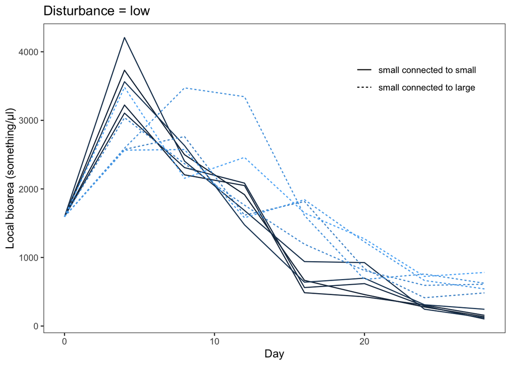

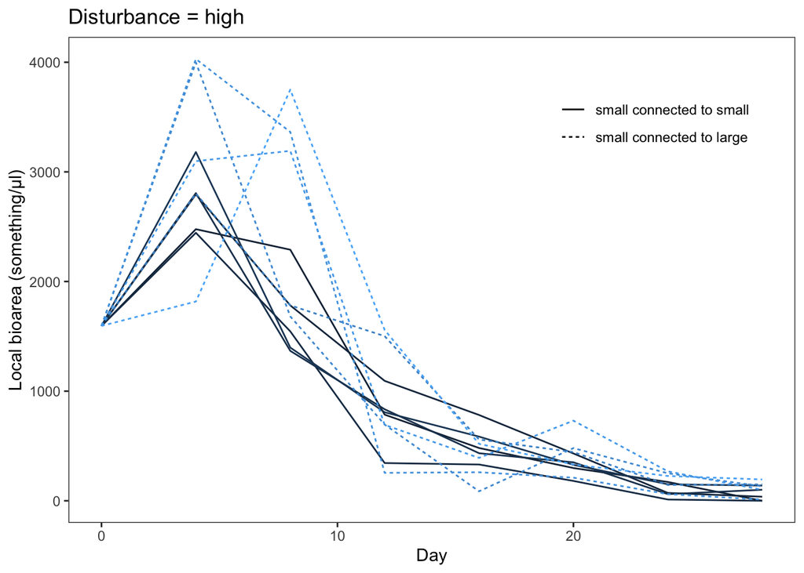

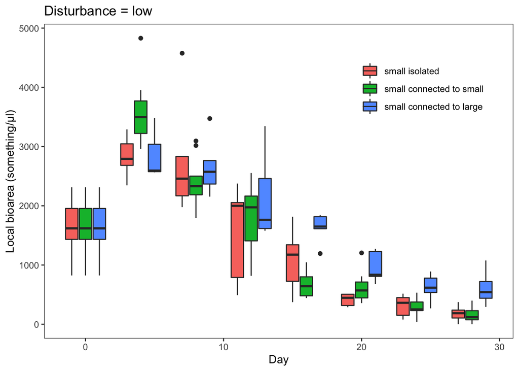

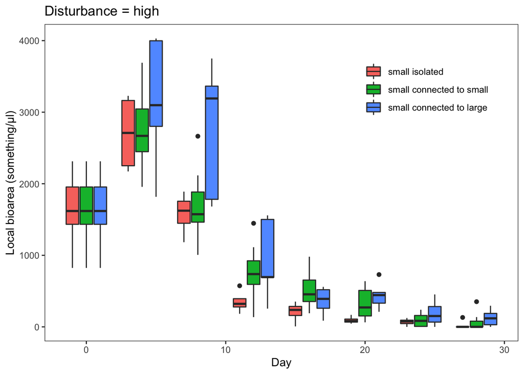

### Large patches

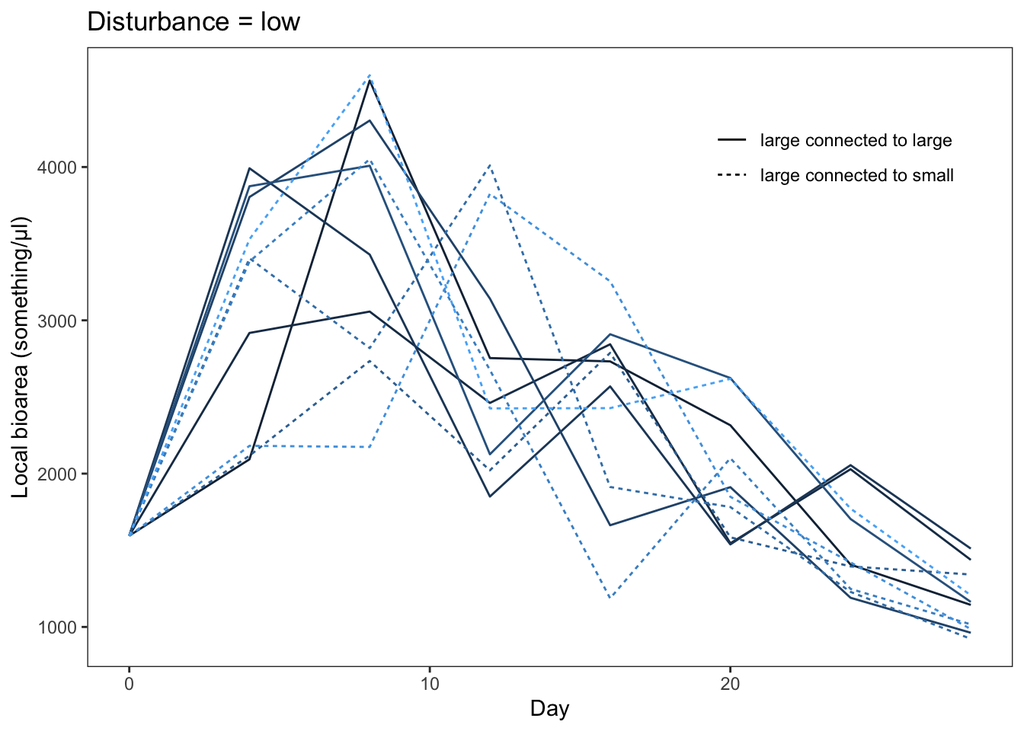

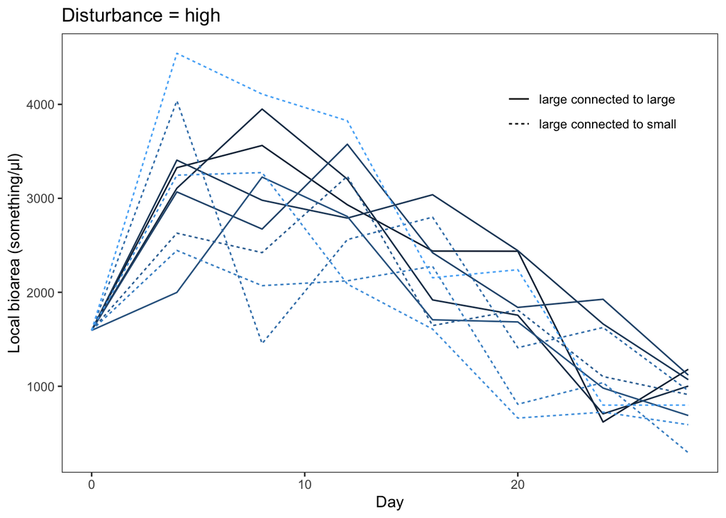

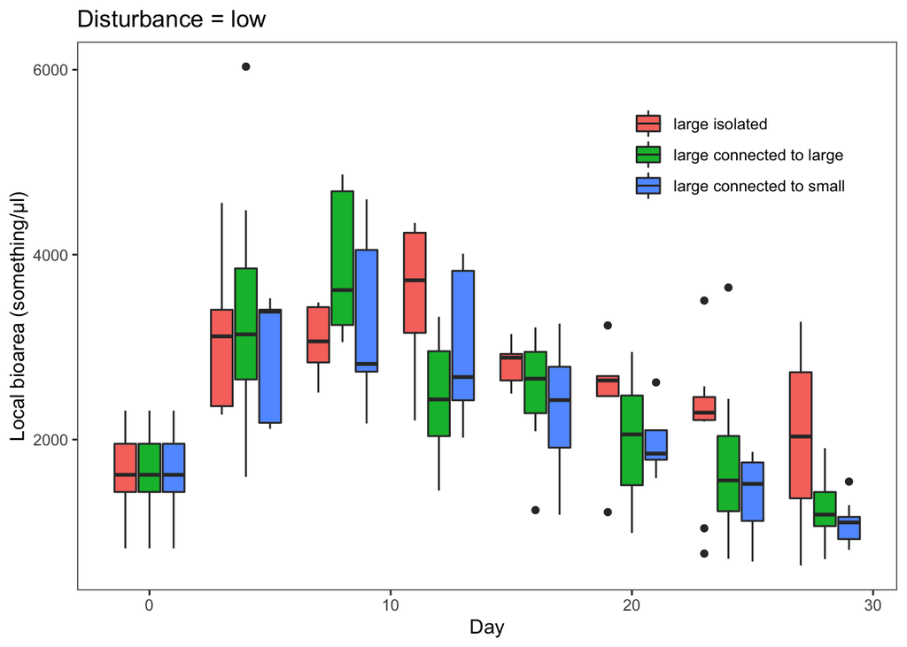

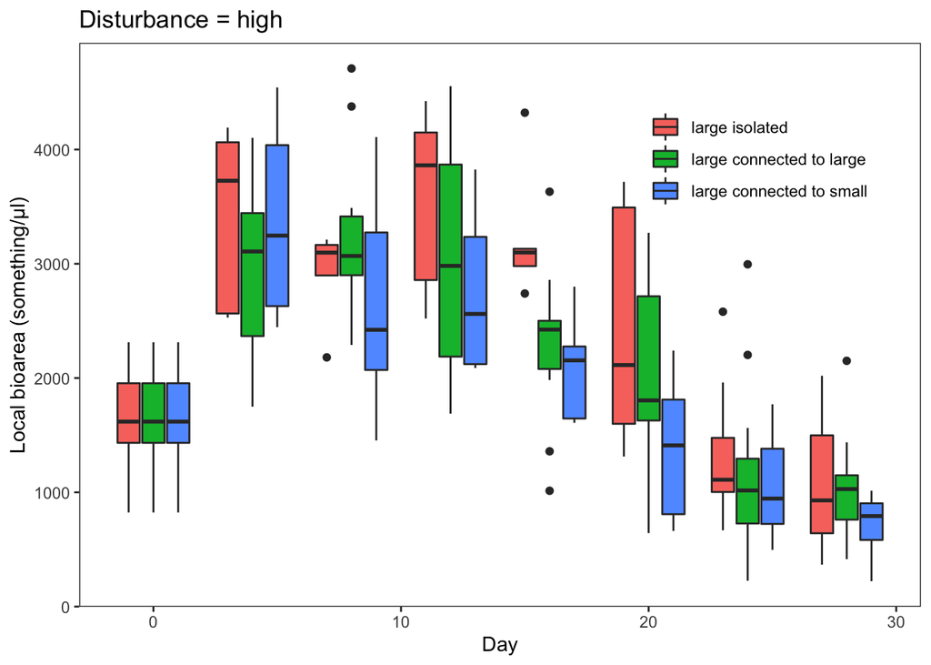

### Figures

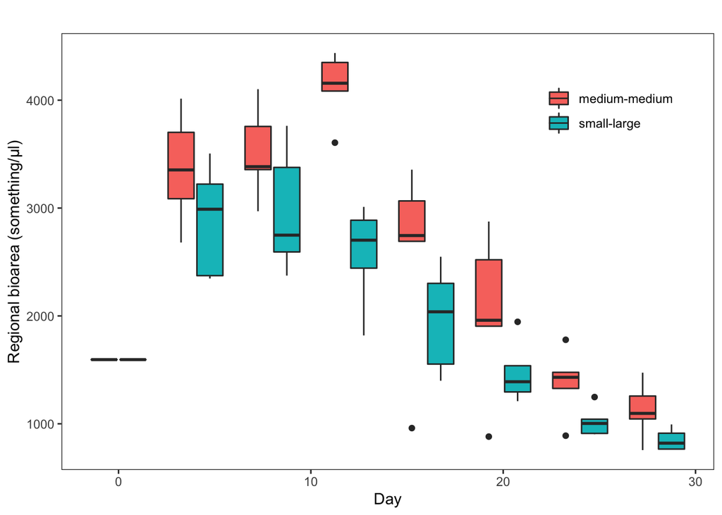

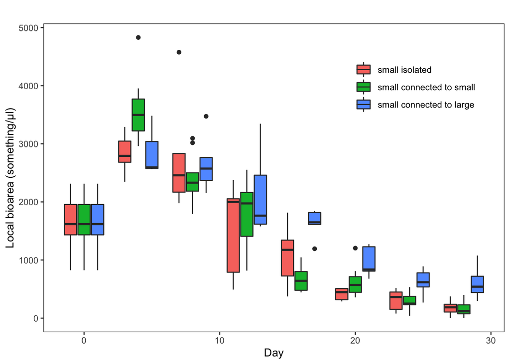

### Other

#### Mixed effects models

- To build the mixed effect models we will use the R package lme4. See page 6 of [this PDF](https://cran.r-project.org/web/packages/lme4/vignettes/lmer.pdf) to know more about the syntaxis of this package.
- To do model diagnostics of mixed effect models, I’m going to look at the following two plots (as suggested by Zuur et al. (2009), page 487):
  - Quantile-quantile plots
  - Partial residual plots
- The effect size of the explaining variables is calculated in the mixed effect models as marginal and conditional r squared. The marginal r squared is how much variance is explained by the fixed effects. The conditional r squared is how much variance is explained by the fixed and the random effects. The marginal and conditional r squared are calculated using the package `MuMIn`. The computation is based on the methods of Nakagawa, Johnson, and Schielzeth (2017). For the coding and interpretation of these r squared check the [documentation for the r.squaredGLMM function](https://rdrr.io/cran/MuMIn/man/r.squaredGLMM.html)

#### Model selection

- I am starting from the largest model and then simplifying because … (see statistical modelling course at ETH).
- I am going to select the best model according to AIC. BIC is better for understanding and AIC for predicting. Halsey (2019) also suggests this approach instead of p values. I’m going to use AIC because I’m interested in knowign how much meta-ecosystem type contributed to the overall regional biomass.

#### Error bars

…

## To do

1. Research which error bars to include. Then including them.

What error bars should I show in the plots? Cumming, Fidler, and Vaux (2007) advises that when we are in the realm of experimental biology and we want to compare treatment and control, we should use inferential error bars, such as the standard error (SE) or the confidence interval (CI). However, they are both not robust to different sample sizes. Therefore, we need a robust measure of scale that is robust to sample size. These are interquartile ranges (IQR) and median absolute deviation (MAD). According to Rousseeuw and Croux (1993), however, MAD is more robust than IQR. The problem, however, is that if I show the median instead of the mean, the patterns of regional and local biomass just disappear. So, I should show something different. Basically, I need to show a error bar that is a robust measure of scale that is robust to sample size and is not based on the median.

2. Re-run the analysis without 106-110, as I overboiled them and then compare it to the analysis with them.
3. Produce boxplots in which points are connected to each other.
4. Include a figure with all the local biomass.
5. Include a figure with all the regional biomass.
6. Model S vs M vs L
7. Model SS vs MM vs LL

## Running time

```
## Time difference of 19.04718 secs
```

## Bibliography

Cumming, Geoff, Fiona Fidler, and David L. Vaux. 2007. “Error bars in experimental biology.” *Journal of Cell Biology* 177 (1): 7–11. https://doi.org/10.1083/jcb.200611141.

Halsey, Lewis G. 2019. “The reign of the p-value is over: What alternative analyses could we employ to fill the power vacuum?” *Biology Letters* 15 (5). https://doi.org/10.1098/rsbl.2019.0174.

Nakagawa, Shinichi, Paul C. D. Johnson, and Holger Schielzeth. 2017. “The coefficient of determination R2 and intra-class correlation coefficient from generalized linear mixed-effects models revisited and expanded.” *Journal of the Royal Society Interface* 14 (134). https://doi.org/10.1098/rsif.2017.0213.

Rousseeuw, Peter J., and Christophe Croux. 1993. “Alternatives to the median absolute deviation.” *Journal of the American Statistical Association* 88 (424): 1273–83. https://doi.org/10.1080/01621459.1993.10476408.

Zuur, Alain F., Elena N. Ieno, Neil Walker, Anatoly A. Saveliev, and Graham M. Smith. 2009. *Mixed effects models and extensions in ecology with R*. Vol. 36. Statistics for Biology and Health. New York, NY: Springer New York. https://doi.org/10.1007/978-0-387-87458-6.